# Affine Tracing — CORMSIS Seminar, 7 May 2026

## Affine Tracing

Affine Tracing

A New Paradigm for Implementing Probabilistic Linear Solvers

Jon Cockayne, CORMSIS Seminar, 7 May 2026

## Co-Authors

- Disha Hegde (UoS)
- Mohamed Adil
- Chris Oates (Newcastle)
- Ilse Ipsen (NC State University)
- Tim Reid

## Outline

1. GP Regression
2. Probabilistic Numerics and Probabilistic Linear Solvers
3. Computation-Aware GPs
4. Affine Tracing
5. Results

## Part 1: Linear Systems

## Linear Systems

- We focus on linear systems of the form

$$Ax = b$$

- Standard solvers (LU, QR, Cholesky) require $\mathcal{O}(d^{3})$ compute to solve.
- Iterative Solvers produce a sequence $(x_{i}) \rightarrow x$.
- If the error $x_{i} - x$ can be made small for small enough $i$, they are more efficient

## Why Should You Care?

- Second order optimisation.
- Linear Programming (e.g. interior point methods).
- Least-squares problems
- …essentially any numerical pipeline.

## Big (GP) Regression Problems

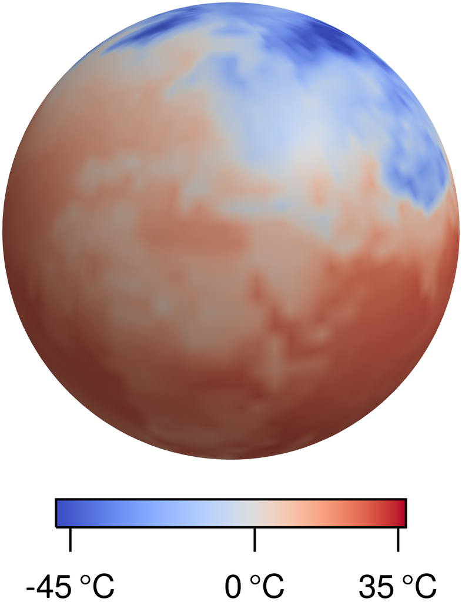

## (My) Motivation: GP Regression / Kriging

- Start from an initial prior distribution $u \sim \mu_{0}:= \mathcal{GP}(m_{0},k_{0})$.
- Assume the data-generating model (DGM):
- $y = u(X_{\text{tr}}) + \zeta$, $X_{\text{tr}} \in \mathcal{X}^{d}$, $\zeta \sim \mathcal{N}(0,\sigma^{2}I)$
- We then update to the **conditional distribution** $u \mid y \sim \mu^{y}:= \mathcal{GP}(m,k)$

$$\begin{matrix}
m(x) & = m_{0}(x) + k_{0}(x,X_{\text{tr}})A^{- 1}(y - m_{0}(X_{\text{tr}})) \\
k(x,x') & = k_{0}(x,x') - k_{0}(x,X_{\text{tr}})A^{- 1}k_{0}(X_{\text{tr}},x') \\
A & = k_{0}(X_{\text{tr}},X_{\text{tr}}) + \sigma^{2}I
\end{matrix}$$

## Posterior Computation and Linear Algebra

$$\begin{matrix}
u \mid y & \sim \mu^{y}:= \mathcal{GP}(m,k) \\
m(x) & = m_{0}(x) + k_{0}(x,X_{\text{tr}})A^{- 1}(y - m_{0}(X_{\text{tr}})) \\
k(x,x') & = k_{0}(x,x') - k_{0}(x,X_{\text{tr}})A^{- 1}k_{0}(X_{\text{tr}},x')
\end{matrix}$$

- $A \in \mathbb{R}^{d \times d}$. Standard “direct” solver:
- Compute $A = LL^{\top}$, $L$ triangular [$\mathcal{O}(d^{3})$]
- Perform forward / backward substitution [$\mathcal{O}(d^{2})$]

## Part 2: Probabilistic Numerics and Probabilistic Linear Solvers

## Numerical Problems

- Given a problem space $\mathcal{A}$ and solution space $\mathcal{X}$, a **numerical method** is a function:

$$f:\mathcal{A} \rightarrow \mathcal{X}$$

- For a problem $P \in \mathcal{A}$ with solution $x \in \mathcal{X}$, **good** numerical methods have $f(P) \approx x$.

## Example: NLA

- Problem: find $x$ in $Ax = b$.
- $\mathcal{X} = \mathbb{R}^{d}$, $\mathcal{P} = \left\{ (A,b):A \in \mathbb{R}^{d \times d},b \in \mathbb{R}^{d},A\text{invertible} \right\}$
- Measure **approximation error** through the error norm $\parallel f((A,b)) - x \parallel$

## Example: NLA

### Examples of Numerical Methods

- LU Factorisation:
- Computes $x$ exactly (ignoring precision), $\mathcal{O}(d^{3})$.
- Iterative Methods:
- Richardson *(GD)*: $f((A,b);x_{i}) = x_{i} + (b - Ax_{i})$
- Each application $\mathcal{O}(d^{2})$ *but converges rather slowly*.
- Many others - e.g. Krylov methods *(CG)*, multigrid, semi-iterations…

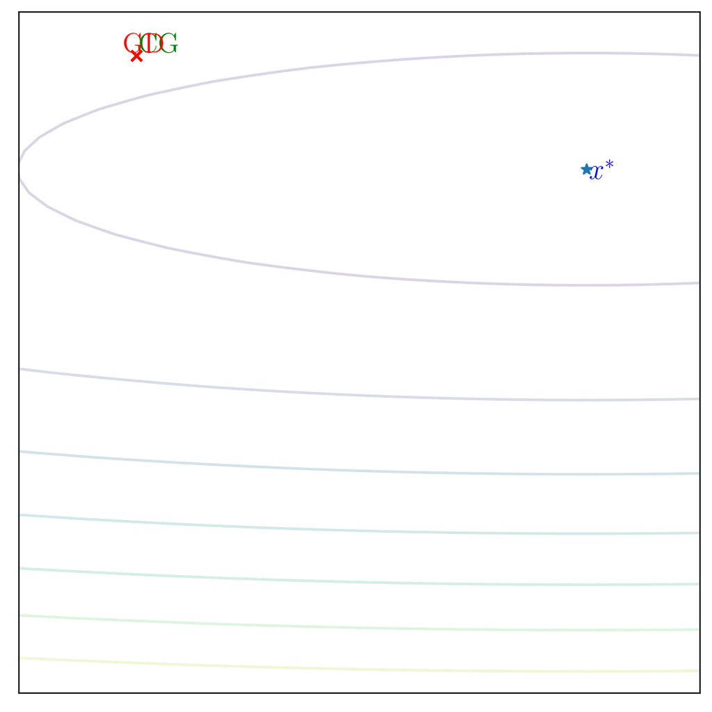

## Early Stopping

- An iterative method is a sequence
- $(x_{i})$ $x_{i} \in \mathbb{R}^{d}$
- Running to convergence can still be expensive.
- Terminating an iteration early leaves error unquantified.
- Existing “worst case” bounds are typically very conservative.

[figure not shown]

## Probabilistic Numerics

- A **probabilistic iterative method** is a sequence
- $(\mu_{i})$ $\mu_{i} \in \mathcal{P}(\mathbb{R}^{d})$
- “Uncertainty” describes the error.
- Probabilistic numerical methods are good if:
- They converge quickly (i.e. $\mu_{i}(B_{\epsilon}^{\mathsf{c}}(x^{\star}))$ is small) **and**
- $\mu_{i}$ *typically* provides a *good representation of the error*.

[figure not shown]

## 2.1: Building PLSs

## Probabilistic Iterative Methods for Linear Systems

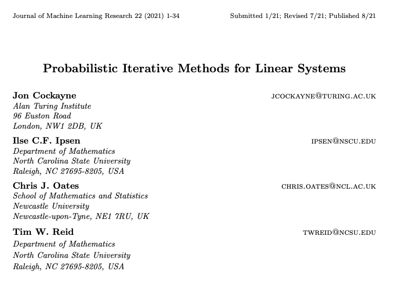

## Iterative Methods

- A (degree 1) iterative method is a sequence of maps $(P_{i})_{i = 1}^{\infty}$, $P_{i}:\mathbb{R}^{d} \rightarrow \mathbb{R}^{d}$.
- Given an initial iterate $x_{0}$, we generate the sequence $x_{i} = P_{i}(x_{i - 1})$.
- We let $P^{i} = P_{i} \circ \ldots \circ P_{1}$, i.e. $x_{i} = P^{i}(x_{0})$.

## Pushforward Methods

- We lift the maps to probability space.
- Given an initial random variable $X_{0}$, $X_{i} = P_{i}(X_{i - 1})$.
- If $X_{0} \sim \mu_{0}$, $X_{i} \sim \mu_{i}$ where $\mu_{i} = (P_{i})_{\sharp}\mu_{i - 1}$.
- (Hence why these are called “pushforward methods”)

[figure not shown]

## Gaussian-Affine PLS

- Many iterative methods are affine:

$$P_{i}(x) = M_{i}x + f_{i}\quad M_{i} \in \mathbb{R}^{d \times d},f_{i} \in \mathbb{R}^{d}$$

- Using a Gaussian prior $\mu_{0} = \mathcal{N}(x_{0},\Sigma_{0})$ we have

$$\mu_{i} = \mathcal{N}(x_{i},\Sigma_{i})\quad\Sigma_{i} = M_{i}\Sigma_{i - 1}M_{i}^{\top}$$

[figure not shown]

## Approach 2: Bayesian Methods

- Phrase this as a **Bayesian inference problem**:
- Take $x \sim \mu_{0}:= \mathcal{N}(x_{0},\Sigma_{0})$
- Condition on **data** of the form $s_{i}^{\top}Ax^{\star} = s_{i}^{\top}b$, $i = 1,\ldots,m$, where $S_{m} = \lbrack s_{1},\ldots,s_{m}\rbrack \in \mathbb{R}^{d \times m}$ has rank $m$.

## Bayesian PLS

- Posterior:

$$\begin{matrix}
x \mid S_{m}^{\top}b & \sim \mu_{m} = \mathcal{N}(x_{m},\Sigma_{m}) \\
x_{m} & = x_{0} + S_{m}(S_{m}^{\top}A\Sigma_{0}A^{\top}S_{m})^{- 1}S_{m}^{\top}b \\
\Sigma_{m} & = \Sigma_{0} - S_{m}(S_{m}^{\top}A\Sigma_{0}A^{\top}S_{m})^{- 1}S_{m}^{\top}
\end{matrix}$$

- The matrix inside the inverse is $m \times m$.
- Cost: $\mathcal{O}(m^{3} + md^{2})$ compute.
- (Methods exist to reduce this cost)

## Bayesian Methods are Pushforward Methods

- Previous work gives the impression that these are **separate methodological approaches**.

**Theorem (Coming Soon)**

Let $(P_{i})$ be a sequence of affine iterative methods with fixed point $x^{\star}$. Then the PIM associated with $P^{i}$ is a Gaussian-affine **Bayesian** PLS with information $S_{i}$ if and only if $P_{i}$ orthogonally projects onto $\ker(\Sigma_{0}AS_{i})$ with-respect-to the $\Sigma_{0}^{- 1}$ inner-product.

## 2.2: Calibrated PLSs

## Calibration of Gaussians

[figure not shown]

$$z_{i} = (\Sigma_{m}^{i})^{- \frac{1}{2}}(x_{m}^{i} - x^{\star ,i})$$

$\mu_{0}$ the prior: an ensemble of problems we wish to test calibratedness wrt.

$$\begin{matrix}
x^{\star ,i} & \sim \mu_{0} \\
z_{i} & \sim N(0,I)
\end{matrix}$$

## Calibration of Gaussian-Affine PLSs

**Definition: Strongly Calibrated PLS.**

Let $\mu_{0} = \mathcal{N}(x_{0},\Sigma_{0})$ and $\mu_{i} = \mathcal{N}(x_{i},\Sigma_{i})$ be the output of a PLS. If $\Sigma_{i}$ is independent of $x^{\star}$, we say that the PLS is **strongly calibrated** if:

$\Sigma_{i}^{- \frac{1}{2}}(x_{i} - X_{0}) \sim \mathcal{N}(0,I)$.

## Calibration of Gaussian-Affine PLSs

**Theorem (Coming Soon)**

Let $P^{i}$ be an affine fixed-point iterative method. Then if $x^{\star} \sim \mu_{0} = \mathcal{N}(x_{0},\Sigma_{0})$, the associated PIM $\mu_{i} = P_{\sharp}^{i}\mu_{0}$ is strongly calibrated.

## Part 3: Computation-Aware GPs

## Computation-Aware Gaussian Processes

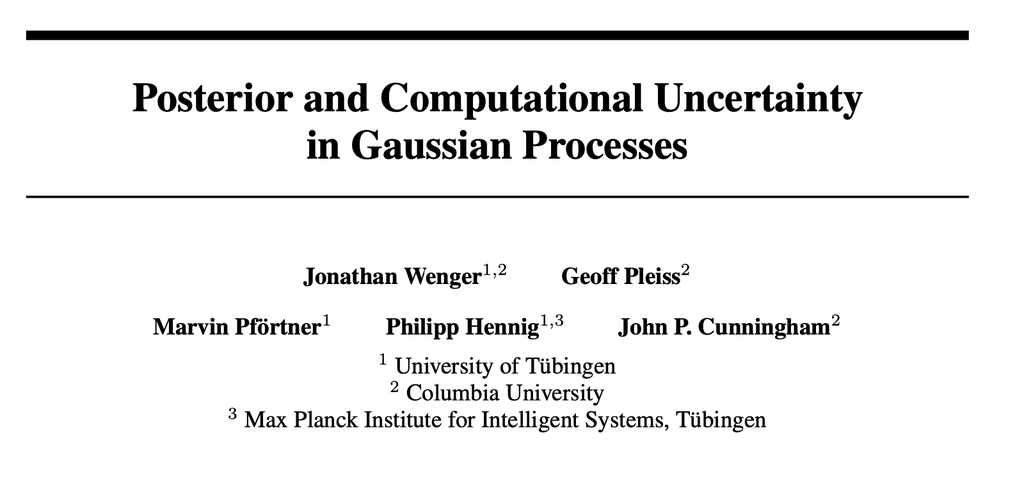

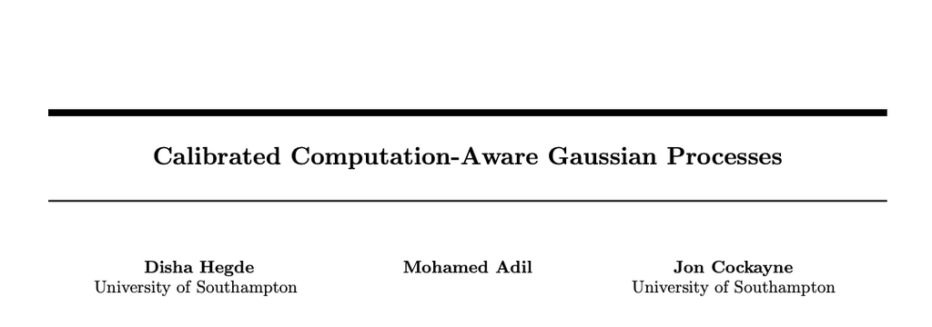

## Recap: Gaussian Processes

$$\begin{matrix}
u \mid y & \sim \mu^{y}:= \mathcal{N}(m,k) \\
m(x) & = m_{0}(x) + k_{0}(x,X_{\text{tr}})A^{- 1}(y - m_{0}(X_{\text{tr}})) \\
k(x,x') & = k_{0}(x,x') - k_{0}(x,X_{\text{tr}})A^{- 1}k_{0}(X_{\text{tr}},x')
\end{matrix}$$

- Standard solvers incur $\mathcal{O}(d^{3})$ computation.
- Goal: fast, calibrated GP posteriors.

## Reparameterisation

- Let $v$ be the solution to the linear system $Av = y - m_{0}(X_{\text{tr}}) = :b$.
- We have $u \mid v,y \sim \mu^{y}(v) = \mathcal{N}(m( \cdot ;v),k)$

$$\begin{matrix}
m(x;v) & = m_{0}(x) + k_{0}(x,X_{\text{tr}})v \\
k(x,x') & = k_{0}(x,x') - k_{0}(x,X_{\text{tr}})A^{- 1}k_{0}(X_{\text{tr}},x')
\end{matrix}$$

## The “Marginalisation Trick”

- Apply a **probabilistic linear solver** to solve $Av = b$.
- Obtain a posterior belief $v \sim \nu:= \mathcal{N}(\overline{v},A^{- 1} - D)$.
- Marginalise $v$:

$$\begin{matrix}
m(x;v) & = m_{0}(x) + k_{0}(x,X_{\text{tr}})v \\
k(x,x') & = k_{0}(x,x') - k_{0}(x,X_{\text{tr}})A^{- 1}k_{0}(X_{\text{tr}},x')
\end{matrix}$$

$$\mapsto\quad \begin{matrix}
\tilde{m}(x) & = m_{0}(x) + k(x,X_{\text{tr}})\overline{v} \\
\tilde{k}(x,x') & = k_{0}(x,x') - k_{0}(x,X_{\text{tr}})Dk_{0}(X_{\text{tr}},x')
\end{matrix}$$

## Calibration of CAGPs

**Theorem (Theorem 4 of [1])**

Assume that the GP model is strongly calibrated (in the sense of [2]) for $(\mu_{0},\text{DGM})$, and that the PLS is strongly calibrated for $N(0,A^{- 1})$ (plus some additional mild technical conditions).

Then the CAGP posterior is strongly calibrated for $(\mu_{0},\text{DGM})$.

Hegde, D., Adil, M., & Cockayne, J. (2025). Calibrated computation-aware Gaussian processes. *AIStats 2025.* doi:10.48550/ARXIV.2410.08796

Cockayne, J., Graham, M. M., Oates, C. J., Sullivan, T. J., & Teymur, O. (2022). Testing Whether a Learning Procedure is Calibrated. *Journal of Machine Learning Research*, *23*(203), 1–36. Retrieved from http://jmlr.org/papers/v23/21-1065.html

## The Inverse Prior

How do we obtain such a posterior belief?

**Theorem (Coming Soon)**

Suppose that $(P_{i})$ is a sequence of affine iterative methods with fixed point $x^{\star}$. Then there exists a matrix ${\overline{M}}_{i}$ and a vector ${\overline{f}}_{i}$ such that $P^{i}(x) = (I - {\overline{M}}_{i}A)x + {\overline{f}}_{i}$.

An immediate corollary is that any PIM with $\mu_{0} = \mathcal{N}(x_{0},A^{- 1})$ has $\Sigma_{i} = A^{- 1} - D_{i}$ for some $D_{i}$.

## …but how do we get the downrate?

- Straightforward to show:

$$D_{i} = {\overline{M}}_{i} + {\overline{M}}_{i}^{\top} - {\overline{M}}_{i}A{\overline{M}}_{i}^{\top}$$

- But ${\overline{M}}_{i}$ is **only available implicitly** - it needs to be computed on paper **for every new PIM** and for **every iteration number.**

## Part 4: Affine Tracing

## More Complex Routines

```python
# Multigrid pseudocode
def multigrid(x_l, b_l):
    s_l = pre_smooth(A_l, b_l, x_l)
    r_l = b_l - A_l @ s_l
    r_next = restrict(r_l)
    e_next = multigrid(0, r_next)
    x_l = s_l + interpolate(e_next)
    return post_smooth(A_l, b_l, x_l)
```

To lift this we need to track **cross-covariances**…

## More Complex Routines

…this is what it looks like algebraically.

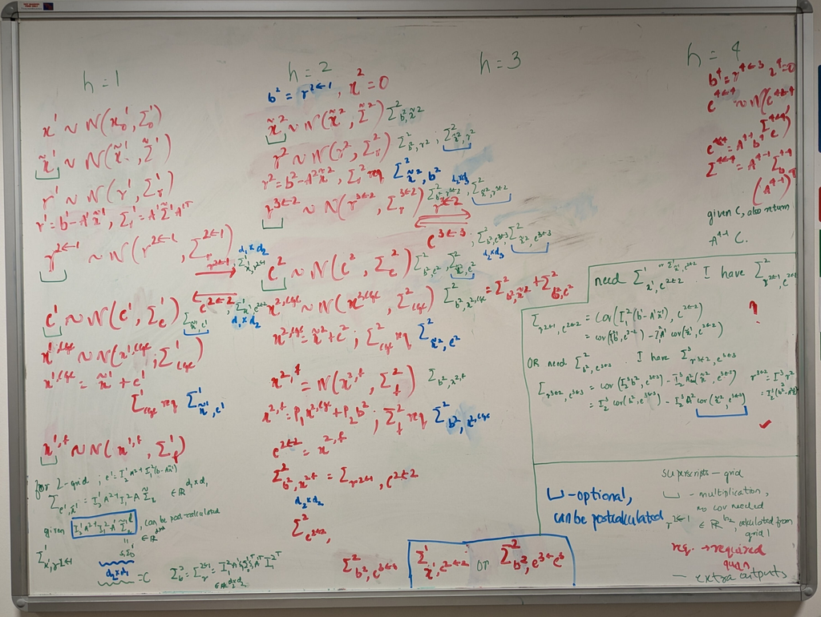

## …but it might be faster!

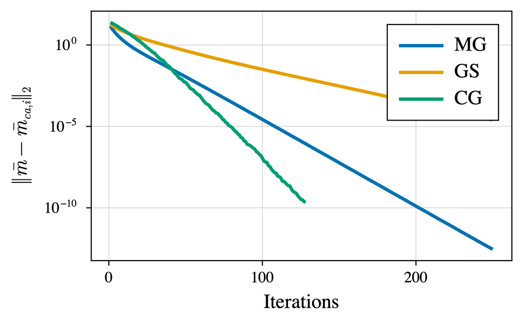

## An Algorithmic Approach

- Any (first order) affine iterative method has the form

$$x_{n + 1} = M_{n + 1}x_{n} + f_{n + 1}$$

- for some $M_{n + 1}$, $f_{n + 1}$.
- E.g. Gauss-Seidel: $x_{n + 1} = L^{- 1}(b - Ux) = L^{- 1}b - L^{- 1}Ux$.
- Can we extract them automatically?

## From Code to PLS

$$x_{n + 1} = L^{- 1}(b - Ux_{n})$$

`x: AffineTracer`

[figure not shown]

```python
import numpy as np
import scipy.linalg as spl

def gauss_seidel(A, b, x):
    L = np.tril(A)
    U = np.triu(A, k=1)
    y = U @ x
    z = b - y
    return spl.solve_triangular(L, z)
```

## Program Transformation

[figure not shown]

## Inverse Priors

- This shows how we can use Affine Tracing to generate an implementation of $P^{i}$ and its linear part ${\overline{G}}_{i} = \prod_{j=i}^{1}G_{j}$.
- We have seen that $G_{i} = (I - M_{i}A)$. We have:

$$D_{i} = S(M_{i}) + \sum_{j=1}^{i-1}G_{i:j + 1}S(M_{j})G_{i:j + 1}^{\top}$$

- We need an implementation of $M_{i}$ to compute the downdate.
- For this we use a (more sophisticated) program transformation.

$$G_{i:j} = \prod_{k=i}^{j}G_{j}$$

## Program Transformation

- We need to compute expressions like $VM_{i} = VG_{i}A^{- 1} - VA^{- 1}$, $V \in \mathbb{R}^{d' \times d}$
- Feed this expression into an **e-graph** *(generated from the traced graph)*.
- Represent linear algebra identities as equivalences in the e-graph.
- Generates equivalent representations and extracts the **minimum cost** representation.

## E-Graph Simplification

[figure not shown]

## Part 5: Results

## AT Implementations can be Faster

- Comparing traced 2-grid multigrid to a hand-implementation.

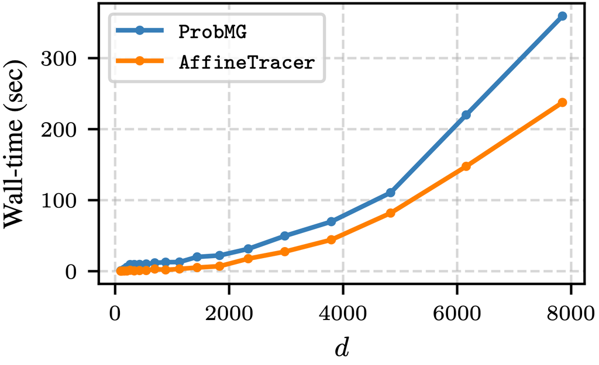

## CAGP Convergence

- Synthetic test problem.
- Draw a sample from a GP prior (Matern 3/2)
- 100x100 grid of training points in $\lbrack 0,1\rbrack^{2}$
- Multigrid uses 40x40 and 30x30 grids
- 5x5 grid as test set

## CAGP Convergence

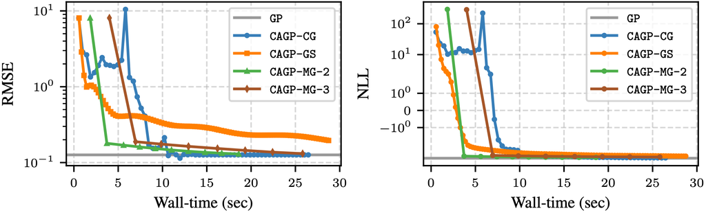

## ERA5 Regression

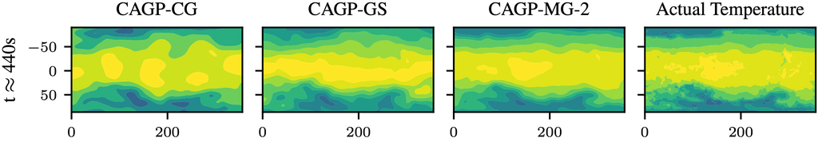

## Conclusions / Challenges

- E-graph component brittle, still requires some hand-simplification (but greatly reduced).
- No numerical analysis.
- Everything in the talk relies (intrinsically) on the Gaussian-affine assumption.
- BUT: the fixed point requirement is much more general!